# Exploring Education Spending

Sahana Jayaraman

8/10/2022

## Load libraries

```r
library(tidyverse)
library(DT)
library(vroom)
library(here)
```

```r
library(ggplot2)
#install.packages("ggdist")
library(ggdist)
```

```r
source("scripts/analysis/covid-edu.R")
```

## ANALYSIS SUMMARY

### THE BIGGEST TAKEAWAYS THUS FAR:

- Overall, LEAs didn’t spent much of their ESSER III money over the course of the 2021-22 school year/summer — more than a year after the federal government began urgently distributing the money to states. Looking at data reported between March and July, we see that 13,534 LEAs across 41 states altogether spent less than 15 percent of the money allocated to them (about 12 percent).
- A whopping 50 percent of the LEAs we analyzed represented nationwide spent 10 percent or less of their ESSER III dollars – at least a quarter spent no money at all.
- The trend continues when we look at districts seemingly in dire need of the money: About half (101) of the 211 districts we analyzed with the highest predicted learning losses spent 5 percent or less of their ESSER III dollars between march and the end of July. 75% of those leas spent less than 16% of their allocated dollars.
- Spending rate varied — in many cases, significantly — between states. About a year after the federal government had distributed two-thirds of ARP ESSER funds to states (March 31, 2022), about 70% of LEAs in California had spent at least some of their allocated money. At the same point, no LEA in Kansas reported spending any money — not a single dollar, according to data published on the state’s public dashboard and collected by Georgetown’s Edunomics lab.

### TOTAL EXPENDITURES AND BY STATE EXPENDITURES

BIG NOTE: This takes into account more than 13,000 local education agencies across 41 different states/cities (DC). We threw out some LEAs because of data inconsistencies/discrepancies. Still other LEAs that supposedly received ESSER III dollars aren’t in here because they weren’t included in FOIA data the states handed over. Important to note that we aren’t looking at the full universe of local education agencies, even within the states for which we had data.

Also important to note that our “states” are just aggregations of the local education agencies in a state. So, we should be referring to them that way: “Local education agencies in Arkansas…”, “School districts in x state…” etc.

Other caveats:

- Edunomics didn’t have data for 4 states
- 3 states had data dates that fell outside our time range (AL, UT, NM)
- Edunomics data for three states had dates we couldn’t confirm as of 08/10/22. In Lousiana and Idaho, we had contact with the states’ public information reps —- in the case of LA, we couldn’t confirm that what edunomics is publishing matches the quarterly data that LA says is published. In Idaho, edunomics has the date last updated as 7/01. Idaho dept. of ed did not publish data through 7/01; the closest date they had was 6/28/22. Asked them for the following file but no answer yet. NJ gave me a bit of the run-around; provided me with a dashboard link but haven’t answered my question on how up-to-date the data is on their portal.

```r
splice_month = function(month_start, month_finish){

expend_month <<- esser_III_db_clean %>%
   select(-percent_spent) %>%
   filter(year == 2022,
          month >= month_start,
          month <= month_finish)%>%
  group_by(state, month) %>%
  summarise(sum_lea_allocation = sum(total_funds_allocated_clean),
            sum_lea_spent =  sum(total_funds_spent_clean),
            percent_spent = (sum_lea_spent/sum_lea_allocation)*100) %>%
  ungroup() %>%
  mutate(total_lea_allocated = sum(sum_lea_allocation),
         total_lea_spent = sum(sum_lea_spent),
         percent_total_spent = (total_lea_spent/total_lea_allocated)*100,
         states_rep = n()) %>%
  arrange(desc(percent_spent))

datatable(expend_month)

}

splice_month(3,7)
```

|  | state | month | sum_lea_allocation | sum_lea_spent | percent_spent | total_lea_allocated | total_lea_spent | percent_total_spent | states_rep |
| --- | --- | --- | --- | --- | --- | --- | --- | --- | --- |
| 1 | AR | 7 | 1128707967 | 305850201 | 27.0973723887961 | 90858025540 | 10901286143 | 11.9981543492828 | 41 |
| 2 | GA | 7 | 3258713044 | 807514576 | 24.7801682779897 | 90858025540 | 10901286143 | 11.9981543492828 | 41 |
| 3 | KY | 6 | 1801095229 | 391695460 | 21.7476263160986 | 90858025540 | 10901286143 | 11.9981543492828 | 41 |
| 4 | MO | 7 | 1762124659 | 352069986 | 19.9798569415514 | 90858025540 | 10901286143 | 11.9981543492828 | 41 |
| 5 | IA | 3 | 663865391 | 131696553 | 19.837839837022 | 90858025540 | 10901286143 | 11.9981543492828 | 41 |
| 6 | HI | 6 | 412530212 | 79386280 | 19.2437493523505 | 90858025540 | 10901286143 | 11.9981543492828 | 41 |
| 7 | WA | 7 | 1672325869 | 316569418 | 18.9298882393836 | 90858025540 | 10901286143 | 11.9981543492828 | 41 |
| 8 | OK | 6 | 1289542518 | 237615010 | 18.4263028696817 | 90858025540 | 10901286143 | 11.9981543492828 | 41 |
| 9 | DE | 6 | 369779073 | 66817883 | 18.0696767012556 | 90858025540 | 10901286143 | 11.9981543492828 | 41 |
| 10 | CO | 6 | 1050438558 | 174934373 | 16.6534607538654 | 90858025540 | 10901286143 | 11.9981543492828 | 41 |

[output cut: 31 more lines]

This breaks down each column of this dataframe. Things to pay attention to here: there are 13534 districts represented. The percent_spent column tells us that at least the 1st quartile (the fist 25%) of districts spent 0 dollars. The median — our second quartile — tells us at least 50 percent of districts spent 10% of their money or less.

```r
summary(esser_III_db_spliced)
```

```
##  last_updated_date   data_date            state           school_district
##  Length:13534       Length:13534       Length:13534       Length:13534
##  Class :character   Class :character   Class :character   Class :character
##  Mode  :character   Mode  :character   Mode  :character   Mode  :character
##
##
##
##  total_funds_allocated_clean total_funds_spent_clean date_decider
##  Min.   :5.700e+02           Min.   :        0       Length:13534
##  1st Qu.:5.603e+05           1st Qu.:        0       Class :character
##  Median :1.361e+06           Median :   122998       Mode  :character
##  Mean   :6.713e+06           Mean   :   805474
##  3rd Qu.:3.672e+06           3rd Qu.:   478270
##  Max.   :4.802e+09           Max.   :223039743
##     new_date               year          month       percent_spent
##  Min.   :2022-03-30   Min.   :2022   Min.   :3.000   Min.   :  0.00
##  1st Qu.:2022-05-04   1st Qu.:2022   1st Qu.:5.000   1st Qu.:  0.00
##  Median :2022-06-29   Median :2022   Median :6.000   Median : 10.00
##  Mean   :2022-06-09   Mean   :2022   Mean   :5.691   Mean   : 17.53
##  3rd Qu.:2022-07-06   3rd Qu.:2022   3rd Qu.:7.000   3rd Qu.: 25.78
##  Max.   :2022-07-25   Max.   :2022   Max.   :7.000   Max.   :100.00
##  school_dist_clean
##  Length:13534
##  Class :character
##  Mode  :character
##
##
##
```

The histogram you see below represents the number of local education agencies (on the y-axis) and the percentages of money they each spent (on the x-axis). That first, very tall bar shows us that ~ 5,000 local education agencies have spent 0-5% of the money they were allocated. The second bar shows you the number of LEAs that spent 5-10% of their dollars, and so on and so forth.

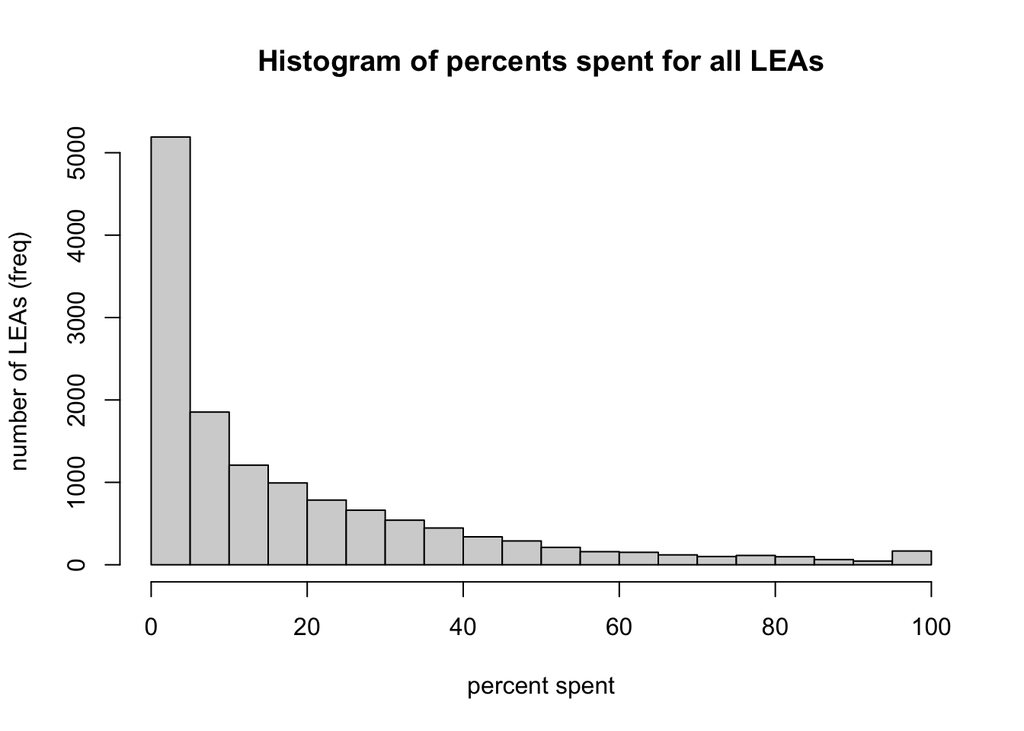

```r
hist(esser_III_db_spliced$percent_spent, breaks = 20, xlab = "percent spent", ylab = "number of LEAs (freq)", main = "Histogram of percents spent for all LEAs")
```

### HIGHEST PREDICTED LEARNING LOSS DISTRICTS AND HOW MUCH THEY SPENT

This datatable represents each of the highest learning loss LEAs we analyzed, handed to us by the researchers at Georgetown’s edunomics lab. Important to note that at least one local education agency didn’t have predicted learning loss estimates, Edunomics says because it was “missing data critical” to producing those estimates — maybe best to couch this with the fact that it’s out of the districts for which Edunomics was able to calculate predicted learning losses.

Here’s how to find out the estimated number of weeks of learning lost for each LEA, and the predicted cost of remedying those learning losses:

1. find the LEA name in the field “district_full”
2. Go to: https://edunomicslab.org/calculator/
3. search the state name in the state dropdown. When that’s set, search the LEA name in the district dropdown.
4. look at the predicted amount of time lost in math and reading and the estimated cost for remedying that loss.

EXAMPLE: Students at Banning Unified school district in CA lost an estimated 26 weeks of learning in math and 23 weeks of learning in reading. Remedying this magnitude of loss would cost an estimate 9,440,728 dollars in tutoring for math and 5,778,118 dollars in tutoring for reading.

```r
datatable(ll_esser_grouped, class = "compact")
```

|  | district_full | school_district.x | state.x | school_dist_clean.x | last_updated_date | data_date | state.y | school_district.y | total_funds_allocated_clean | total_funds_spent_clean | date_decider | new_date | year | month | percent_spent | school_dist_clean.y | dist | is_five_or_less |
| --- | --- | --- | --- | --- | --- | --- | --- | --- | --- | --- | --- | --- | --- | --- | --- | --- | --- | --- |
| 1 | Anchorage School District | anchorage school district | AK | anchorage |  | 7/18/22 | AK | anchorage school district | 116333946 | 1066516 | slash | 2022-07-18 | 2022 | 7 | 0.916771103079405 | anchorage | 0 | True |
| 2 | Dillingham City School District | dillingham city school district | AK | dillingham city |  | 7/18/22 | AK | dillingham city school district | 999508 | 539734 | slash | 2022-07-18 | 2022 | 7 | 53.9999679842483 | dillingham city | 0 | False |
| 3 | Fairbanks North Star Borough School District | fairbanks north star borough school district | AK | fairbanks north star borough |  | 7/18/22 | AK | fairbanks north star borough school district | 22851896 | 3324148 | slash | 2022-07-18 | 2022 | 7 | 14.5464866460096 | fairbanks north star borough | 0 | False |
| 4 | Lower Kuskokwim School District | lower kuskokwim school district | AK | lower kuskokwim |  | 7/18/22 | AK | lower kuskokwim school district | 31047342 | 1356909 | slash | 2022-07-18 | 2022 | 7 | 4.37045142221837 | lower kuskokwim | 0 | True |
| 5 | North Slope Borough School District | north slope borough school district | AK | north slope borough |  | 7/18/22 | AK | north slope borough school district | 3615542 | 24741 | slash | 2022-07-18 | 2022 | 7 | 0.684295743210838 | north slope borough | 0 | True |
| 6 | Blytheville School District | blytheville school district | AR | blytheville |  | 7/14/22 | AR | blytheville school district | 11594172 | 2711527 | slash | 2022-07-14 | 2022 | 7 | 23.3869827013089 | blytheville | 0 | False |
| 7 | Camden Fairview School Dist. | camden fairview school district | AR | camden fairview |  | 7/14/22 | AR | camden fairview school district | 8280967 | 1559408 | slash | 2022-07-14 | 2022 | 7 | 18.8312307004725 | camden fairview | 0 | False |
| 8 | Forrest City School District | forrest city school district | AR | forrest city |  | 7/14/22 | AR | forrest city school district | 16822026 | 2558860 | slash | 2022-07-14 | 2022 | 7 | 15.2113663360168 | forrest city | 0 | False |
| 9 | Pine Bluff School District | pine bluff school district | AR | pine bluff |  | 7/14/22 | AR | pine bluff school district | 23608366 | 103054 | slash | 2022-07-14 | 2022 | 7 | 0.436514750745562 | pine bluff | 0 | True |
| 10 | Prescott School District | prescott school district | AR | prescott |  | 7/14/22 | AR | prescott school district | 2557752 | 1193355 | slash | 2022-07-14 | 2022 | 7 | 46.6563998386083 | prescott | 0 | False |

[output cut: 201 more lines]

This breaks down each column of this highest predicted learning loss districts dataframe. Things to pay attention to here: there are 211 districts represented. The percent_spent column tells us that at least the 1st quartile (the fist 25%) of districts spent 0 dollars. The is_five_or_less column tells us that nearly 50 percent (101) of the 211 districts spent 5% or less of their allocated dollars

```r
summary(ll_esser_grouped)
```

```
##  district_full      school_district.x    state.x          school_dist_clean.x
##  Length:211         Length:211         Length:211         Length:211
##  Class :character   Class :character   Class :character   Class :character
##  Mode  :character   Mode  :character   Mode  :character   Mode  :character
##
##
##
##  last_updated_date   data_date           state.y          school_district.y
##  Length:211         Length:211         Length:211         Length:211
##  Class :character   Class :character   Class :character   Class :character
##  Mode  :character   Mode  :character   Mode  :character   Mode  :character
##
##
##
##  total_funds_allocated_clean total_funds_spent_clean date_decider
##  Min.   :   267725           Min.   :       0        Length:211
##  1st Qu.:  5131536           1st Qu.:       0        Class :character
##  Median : 12557230           Median :  399760        Mode  :character
##  Mean   : 38753813           Mean   : 3240892
##  3rd Qu.: 31462465           3rd Qu.: 2006189
##  Max.   :518186972           Max.   :57418601
##     new_date               year          month       percent_spent
##  Min.   :2022-03-30   Min.   :2022   Min.   :3.000   Min.   : 0.00
##  1st Qu.:2022-05-16   1st Qu.:2022   1st Qu.:5.000   1st Qu.: 0.00
##  Median :2022-06-24   Median :2022   Median :6.000   Median : 5.30
##  Mean   :2022-06-11   Mean   :2022   Mean   :5.706   Mean   :12.29
##  3rd Qu.:2022-07-06   3rd Qu.:2022   3rd Qu.:7.000   3rd Qu.:15.63
##  Max.   :2022-07-25   Max.   :2022   Max.   :7.000   Max.   :86.12
##  school_dist_clean.y      dist        is_five_or_less
##  Length:211          Min.   :0.0000   Mode :logical
##  Class :character    1st Qu.:0.0000   FALSE:110
##  Mode  :character    Median :0.0000   TRUE :101
##                      Mean   :0.3223
##                      3rd Qu.:1.0000
##                      Max.   :2.0000
```

The histogram you see below represents the number of local education agencies (on the y-axis) and the percentages of money they each spent (on the x-axis). That first, very tall bar shows us that ~ 100 local education agencies have spent 0-5% of the money they were allocated. The second bar shows you the number of LEAs that spent 5-10% of their dollars, and so on and so forth.

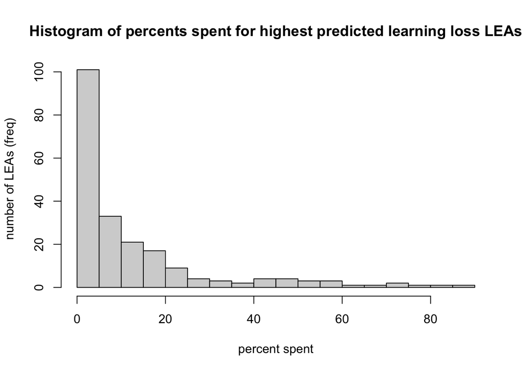

```r
hist(ll_esser_grouped$percent_spent, breaks = 20, xlab = "percent spent", ylab = "number of LEAs (freq)", main = "Histogram of percents spent for highest predicted learning loss LEAs")
```